# Behavioral Economics Analysis

Authors

Yvan Richard

Samuel Payne

Published

May 14, 2026

# Foreword

This notebook conducts a statistical analysis of the behavioral finance dataset. The goals are multiple:

- Define the key variables
- Define the research question and hypotheses
- Perform an exploratory data analysis (EDA)
- Conduct a three-way ANOVA
- Conduct a linear regression analysis
- Perform post-hoc tests and visualize interaction effects

Below are the necessary Python imports for this analysis.

```python
import numpy as np
import pandas as pd
import matplotlib.pyplot as plt
import seaborn as sns
import scipy.stats as stats
import statsmodels.api as sm
from statsmodels.formula.api import ols
from statsmodels.stats.diagnostic import het_breuschpagan
```

# 1. Data Loading and Variable Definition

## 1.1. Load the Dataset

First, we load the dataset into a pandas DataFrame.

```python
# Load the dataset from pickle
data = pd.read_pickle('../data/data.pkl')

# Display the first few rows of the dataset
data.head(3)
```

|  | media_attention | exposure_level | industry | buying_intention |
| --- | --- | --- | --- | --- |
| 0 | Google Search | Low | Industry A | 3 |
| 1 | Google Search | Low | Industry A | 2 |
| 2 | Google Search | Low | Industry A | 2 |

We also inspect the structure of the dataset.

```python
# Get information about the dataset
data.info()
```

```
<class 'pandas.DataFrame'>
RangeIndex: 720 entries, 0 to 719
Data columns (total 4 columns):
 #   Column            Non-Null Count  Dtype
---  ------            --------------  -----
 0   media_attention   720 non-null    category
 1   exposure_level    720 non-null    category
 2   industry          720 non-null    category
 3   buying_intention  720 non-null    int64
dtypes: category(3), int64(1)
memory usage: 8.0 KB
```

As verified by the cleaning pipeline `src/clean_xlsx.py`, there are no missing values in the dataset. Furthermore, the output shows that the columns `media_attention`, `exposure_level`, and `industry` are categorical variables, which is consistent with our expectations.

## 1.2. Variable Definition

Our statistical analysis relies on the following variables.

| Variable Name | Description | Type | Role |
| --- | --- | --- | --- |
| `media_attention` | The type of media consulted: `Google Search`, `News`, or `Social Media` | Categorical | Independent Variable |
| `exposure_level` | The level of media exposure: `Low` or `High` | Categorical | Independent Variable |
| `industry` | The stock industry: `Industry A` or `Industry B` | Categorical | Independent Variable |
| `buying_intention` | The buying intention of the participant, measured from 1 to 5 | Numerical / Ordinal | Dependent Variable |

# 2. Research Question and Hypotheses

The goal of this statistical analysis is to investigate the impact of media attention, exposure level, and industry on the buying intention of participants.

**NoteResearch Question**

Does the type of media attention, the level of exposure, and the type of stock industry influence retail investors’ buying intention?

To answer this research question, we formulate the following hypotheses:

**NoteHypotheses**

- **H1**: Stocks with high exposure will produce higher buying intention than stocks with low exposure.
- **H2**: The type of media attention will affect buying intention. For example, social media attention may create stronger investor interest than Google Search or news attention.
- **H3**: Buying intention may differ depending on the stock industry.
- **H4**: There may be interaction effects between media type, exposure level, and stock industry, meaning that the effect of one factor may depend on the level of another factor.

# 3. Exploratory Data Analysis

## 3.1. Univariate Analysis

In this section, we compute descriptive statistics for the dependent variable and independent variables. We also visualize the distribution of the dependent variable `buying_intention`.

### Summary Statistics

#### Dependent Variable

We first compute the frequency distribution for the dependent variable `buying_intention`.

```python
# Generate value counts for the dependent variable
summary_counts = data['buying_intention'].value_counts().sort_index()

print("Value Counts for Buying Intention:")
print(summary_counts)
```

```
Value Counts for Buying Intention:
buying_intention
1     14
2    184
3    348
4    158
5     16
Name: count, dtype: int64
```

We also compute descriptive statistics for `buying_intention`.

```python
# Generate summary statistics for the dependent variable
summary_stats = data['buying_intention'].describe()

print("Summary Statistics for Buying Intention:")
print(summary_stats)
```

```
Summary Statistics for Buying Intention:
count    720.000000
mean       2.969444
std        0.801014
min        1.000000
25%        2.000000
50%        3.000000
75%        3.000000
max        5.000000
Name: buying_intention, dtype: float64
```

#### Independent Variables

Now we compute value counts for the independent variables, which are categorical.

```python
# Generate value counts for the independent variables
for col in ['media_attention', 'exposure_level', 'industry']:
    print(f"Value Counts for {col}:")
    print(data[col].value_counts())
    print("\n")
```

```
Value Counts for media_attention:
media_attention
Google Search    240
News             240
Social Media     240
Name: count, dtype: int64


Value Counts for exposure_level:
exposure_level
High    360
Low     360
Name: count, dtype: int64


Value Counts for industry:
industry
Industry A    360
Industry B    360
Name: count, dtype: int64
```

This confirms that the synthetic dataset provided for the project is balanced across the different categories of the independent variables.

### Distribution of Buying Intention

Since the independent variables are balanced, we focus on visualizing the distribution of the dependent variable `buying_intention`.

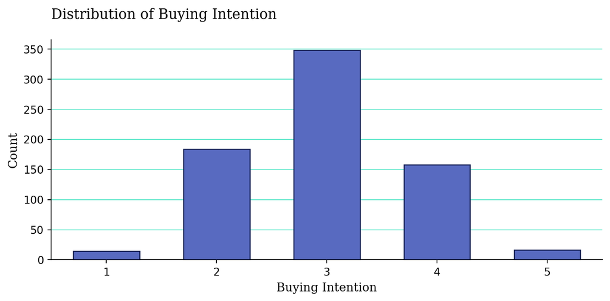

```python
# Create figure
fig, ax = plt.subplots(figsize=(8, 4))

# Plot the distribution of the dependent variable
sns.countplot(
    x='buying_intention',
    data=data,
    ax=ax,
    color='#475ED1',
    edgecolor='#141F52',
    width=0.6,
    zorder=3
)

# Aesthetic customizations
ax.set_title(
    'Distribution of Buying Intention',
    fontsize=13,
    loc='left',
    family='serif',
    pad=20
)
ax.set_xlabel('Buying Intention', fontsize=11, family='serif')
ax.set_ylabel('Count', fontsize=11, family='serif')
ax.set_xticks(range(5))
ax.set_xticklabels(['1', '2', '3', '4', '5'])
ax.grid(axis='y', linestyle='-', alpha=0.8, color='#36E2BD', zorder=0)
ax.spines['top'].set_visible(False)
ax.spines['right'].set_visible(False)

plt.tight_layout()
# plt.savefig('../results/plots/buying_intention_distribution.pdf', dpi=300)
plt.show()
```

The distribution of `buying_intention` is centered around the middle of the 1–5 scale. Since the dependent variable is ordinal and discrete, the distribution should not be interpreted as perfectly continuous. However, the distribution is sufficiently informative for comparing average buying intention across experimental groups.

## 3.2. Bivariate Analysis

In this section, we explore the relationships between the dependent variable `buying_intention` and each of the independent variables: `media_attention`, `exposure_level`, and `industry`.

Since `buying_intention` is ordinal, we use boxplots to visualize the relationship between buying intention and each categorical independent variable.

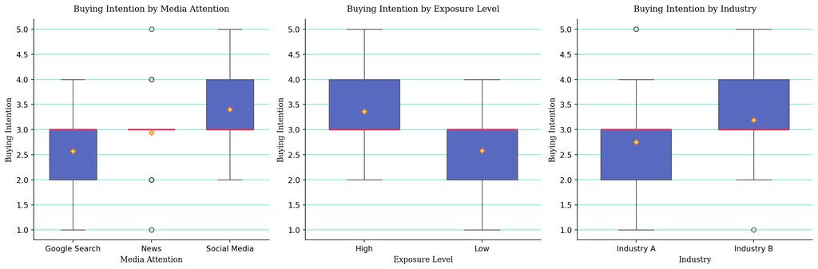

```python
# Create figure
fig, ax = plt.subplots(1, 3, figsize=(15, 5))

# Boxplots
for i, col in enumerate(['media_attention', 'exposure_level', 'industry']):
    sns.boxplot(
        x=col,
        y='buying_intention',
        data=data,
        ax=ax[i],
        color='#475ED1',
        width=0.6,
        showmeans=True,
        meanprops={
            'marker': 'D',
            'markerfacecolor': '#FBD051',
            'markeredgecolor': '#F97A1F',
            'markersize': 5
        },
        medianprops={
            'color': '#E2365B',
            'linewidth': 2
        }
    )

    ax[i].set_title(
        f'Buying Intention by {col.replace("_", " ").title()}',
        fontsize=11,
        loc='center',
        family='serif',
        pad=10
    )
    ax[i].set_xlabel(col.replace("_", " ").title(), fontsize=10, family='serif')
    ax[i].set_ylabel('Buying Intention', fontsize=10, family='serif')
    ax[i].grid(axis='y', linestyle='-', alpha=0.8, color='#36E2BD')
    ax[i].spines['top'].set_visible(False)
    ax[i].spines['right'].set_visible(False)

plt.tight_layout()
plt.savefig('../results/plots/bivariate_analysis.pdf', bbox_inches='tight')
plt.show()
```

**Interpretation of the Boxplots**

The figure presents the distribution of buying intention across the three main experimental dimensions: `media_attention`, `exposure_level`, and `industry`. The **yellow** diamonds represent mean values, while the **red** lines indicate median values. Overall, the boxplots suggest visible differences in buying intention across treatment categories.

**Warning**

The following interpretations are based on visual inspection of the boxplots and should be considered preliminary. Formal statistical tests are needed to confirm these observations.

First, buying intention appears highest for respondents exposed through **Social Media**. The median is around 3, but the upper quartile reaches 4 and the distribution extends up to 5, suggesting that social media exposure is associated with relatively stronger buying intention. By contrast, **Google Search** displays a lower central tendency, with most observations concentrated between 2 and 3. The **News** category is more concentrated around a buying intention of 3.

# 4. Statistical Experiments

## 4.1. ANOVA

### Estimation and Results

To formally test the effects of the independent variables on buying intention, we perform a three-way ANOVA. This allows us to assess the main effects of `media_attention`, `exposure_level`, and `industry`, as well as their interaction effects.

```python
# Fit the ANOVA model
model = ols(
    'buying_intention ~ C(media_attention) * C(exposure_level) * C(industry)',
    data=data
).fit()

anova_table = sm.stats.anova_lm(model, typ=2)

print(anova_table)
```

```
                                                      sum_sq     df  \
C(media_attention)                                 82.869444    2.0
C(exposure_level)                                 108.888889    1.0
C(industry)                                        34.672222    1.0
C(media_attention):C(exposure_level)                6.552778    2.0
C(media_attention):C(industry)                      0.086111    2.0
C(exposure_level):C(industry)                       0.088889    1.0
C(media_attention):C(exposure_level):C(industry)    0.836111    2.0
Residual                                          227.333333  708.0

                                                           F        PR(>F)
C(media_attention)                                129.043035  1.645026e-48
C(exposure_level)                                 339.120235  3.575341e-62
C(industry)                                       107.982111  1.226986e-23
C(media_attention):C(exposure_level)               10.203886  4.277354e-05
C(media_attention):C(industry)                      0.134091  8.745328e-01
C(exposure_level):C(industry)                       0.276833  5.989494e-01
C(media_attention):C(exposure_level):C(industry)    1.301979  2.726433e-01
Residual                                                 NaN           NaN
```

We can also save the ANOVA results to a DataFrame.

```python
anova_df = pd.DataFrame(anova_table)

anova_df
```

|  | sum_sq | df | F | PR(>F) |
| --- | --- | --- | --- | --- |
| C(media_attention) | 82.869444 | 2.0 | 129.043035 | 1.645026e-48 |
| C(exposure_level) | 108.888889 | 1.0 | 339.120235 | 3.575341e-62 |
| C(industry) | 34.672222 | 1.0 | 107.982111 | 1.226986e-23 |
| C(media_attention):C(exposure_level) | 6.552778 | 2.0 | 10.203886 | 4.277354e-05 |
| C(media_attention):C(industry) | 0.086111 | 2.0 | 0.134091 | 8.745328e-01 |
| C(exposure_level):C(industry) | 0.088889 | 1.0 | 0.276833 | 5.989494e-01 |
| C(media_attention):C(exposure_level):C(industry) | 0.836111 | 2.0 | 1.301979 | 2.726433e-01 |
| Residual | 227.333333 | 708.0 | NaN | NaN |

To further complete the analysis, we compute partial eta squared, $\eta^2_p$, for each effect in the ANOVA table.

$$\eta^2_p = \frac{SS_{effect}}{SS_{effect} + SS_{error}}$$

We collect the residual sum of squares from the ANOVA table and then compute partial eta squared for each effect. The value for the residual row is set to `NaN` because it does not represent an effect of interest.

```python
# Copy ANOVA table
anova_df = anova_table.copy()

# Extract residual sum of squares
ss_error = anova_df.loc["Residual", "sum_sq"]

# Compute partial eta squared
anova_df["partial_eta_sq"] = anova_df["sum_sq"] / (anova_df["sum_sq"] + ss_error)

# Remove value for residual row
anova_df.loc["Residual", "partial_eta_sq"] = np.nan

anova_df
```

|  | sum_sq | df | F | PR(>F) | partial_eta_sq |
| --- | --- | --- | --- | --- | --- |
| C(media_attention) | 82.869444 | 2.0 | 129.043035 | 1.645026e-48 | 0.267146 |
| C(exposure_level) | 108.888889 | 1.0 | 339.120235 | 3.575341e-62 | 0.323860 |
| C(industry) | 34.672222 | 1.0 | 107.982111 | 1.226986e-23 | 0.132334 |
| C(media_attention):C(exposure_level) | 6.552778 | 2.0 | 10.203886 | 4.277354e-05 | 0.028017 |
| C(media_attention):C(industry) | 0.086111 | 2.0 | 0.134091 | 8.745328e-01 | 0.000379 |
| C(exposure_level):C(industry) | 0.088889 | 1.0 | 0.276833 | 5.989494e-01 | 0.000391 |
| C(media_attention):C(exposure_level):C(industry) | 0.836111 | 2.0 | 1.301979 | 2.726433e-01 | 0.003664 |
| Residual | 227.333333 | 708.0 | NaN | NaN | NaN |

The ANOVA table now includes the sum of squares, degrees of freedom, F-statistics, p-values, and partial eta squared for each effect. This allows us to evaluate both statistical significance and effect size.

### Assumptions Check

We check the assumptions of the ANOVA test. These include:

1. **Independence of observations**: This is assumed to be ensured by the experimental design.
2. **Normality of residuals**: This can be checked by plotting the residuals and performing a normality test.

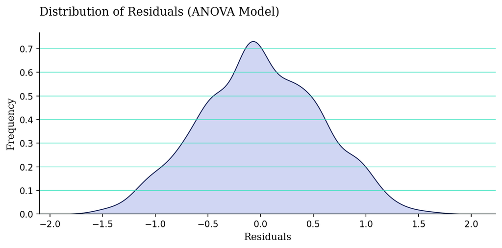

```python
# Extract residuals
residuals = model.resid

# Plot residuals
fig, ax = plt.subplots(figsize=(8, 4))

sns.kdeplot(
    residuals,
    fill=True,
    ax=ax,
    color='#475ED1',
    edgecolor='#141F52'
)

ax.set_title(
    'Distribution of Residuals (ANOVA Model)',
    fontsize=13,
    loc='left',
    family='serif',
    pad=20
)
ax.set_xlabel('Residuals', fontsize=11, family='serif')
ax.set_ylabel('Frequency', fontsize=11, family='serif')
ax.grid(axis='y', linestyle='-', alpha=0.8, color='#36E2BD', zorder=0)
ax.spines['top'].set_visible(False)
ax.spines['right'].set_visible(False)

plt.tight_layout()
# plt.savefig('../results/plots/residuals_distribution.pdf', dpi=300)
plt.show()
```

We also perform the Shapiro-Wilk test for normality of residuals.

```python
# Perform Shapiro-Wilk test
shapiro_test = stats.shapiro(residuals)

print("Shapiro-Wilk test:", shapiro_test)
```

```
Shapiro-Wilk test: ShapiroResult(statistic=np.float64(0.9903988126690617), pvalue=np.float64(0.00012157601337535681))
```

The Shapiro-Wilk test may reject the null hypothesis of normally distributed residuals. However, given the relatively large sample size, this test can be highly sensitive, meaning that even minor departures from normality can become statistically significant. Therefore, the test should be interpreted together with graphical diagnostics.

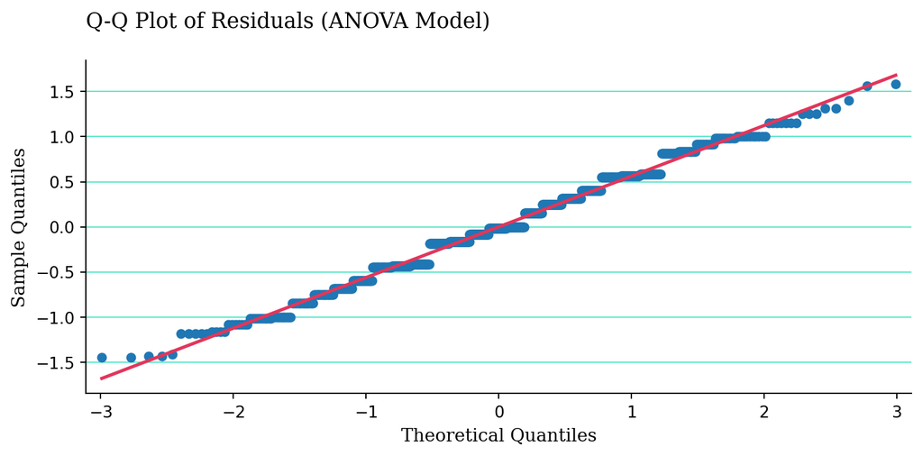

```python
# Q-Q plot of residuals
fig, ax = plt.subplots(figsize=(8, 4))

qq = sm.qqplot(residuals, line='s', ax=ax, color='#475ED1', markersize=5)

# Customize the reference line manually
qq.axes[0].get_lines()[1].set_color('#E2365B')
qq.axes[0].get_lines()[1].set_linewidth(2)

ax.set_title(
    'Q-Q Plot of Residuals (ANOVA Model)',
    fontsize=13,
    loc='left',
    family='serif',
    pad=20
)
ax.set_xlabel('Theoretical Quantiles', fontsize=11, family='serif')
ax.set_ylabel('Sample Quantiles', fontsize=11, family='serif')
ax.grid(axis='y', linestyle='-', alpha=0.8, color='#36E2BD', zorder=0)
ax.spines['top'].set_visible(False)
ax.spines['right'].set_visible(False)

plt.tight_layout()
# plt.savefig('../results/plots/residuals_qqplot.pdf', bbox_inches='tight')
plt.show()
```

For the final report, we can also plot the residual density and Q-Q plot together.

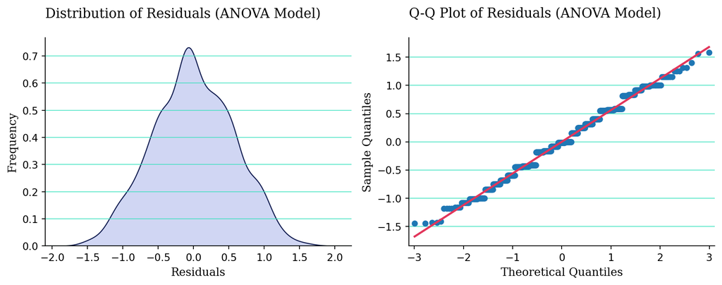

```python
# Create figure
fig, ax = plt.subplots(1, 2, figsize=(10, 4))

# Plot the distribution of residuals
sns.kdeplot(
    residuals,
    fill=True,
    ax=ax[0],
    color='#475ED1',
    edgecolor='#141F52'
)

ax[0].set_title(
    'Distribution of Residuals (ANOVA Model)',
    fontsize=13,
    loc='left',
    family='serif',
    pad=20
)
ax[0].set_xlabel('Residuals', fontsize=11, family='serif')
ax[0].set_ylabel('Frequency', fontsize=11, family='serif')
ax[0].grid(axis='y', linestyle='-', alpha=0.8, color='#36E2BD', zorder=0)
ax[0].spines['top'].set_visible(False)
ax[0].spines['right'].set_visible(False)

# Q-Q plot of residuals
qq = sm.qqplot(residuals, line='s', ax=ax[1], color='#475ED1', markersize=5)

# Customize the reference line manually
qq.axes[1].get_lines()[1].set_color('#E2365B')
qq.axes[1].get_lines()[1].set_linewidth(2)

ax[1].set_title(
    'Q-Q Plot of Residuals (ANOVA Model)',
    fontsize=13,
    loc='left',
    family='serif',
    pad=20
)
ax[1].set_xlabel('Theoretical Quantiles', fontsize=11, family='serif')
ax[1].set_ylabel('Sample Quantiles', fontsize=11, family='serif')
ax[1].grid(axis='y', linestyle='-', alpha=0.8, color='#36E2BD', zorder=0)
ax[1].spines['top'].set_visible(False)
ax[1].spines['right'].set_visible(False)

plt.tight_layout()
# plt.savefig('../results/plots/residuals_diagnostics.pdf', bbox_inches='tight')
plt.show()
```

The combined diagnostic plots suggest that the residuals do not show strong departures from normality. Even if the Shapiro-Wilk test is statistically significant, this may be due to the large sample size. Therefore, we can reasonably proceed with the ANOVA results while acknowledging this limitation.

### Discussion of ANOVA Results

The results suggest that buying intention differs across media attention groups, exposure levels, and industries. The interaction effects indicate that the influence of one variable may depend on the level of another variable. These findings motivate the regression analysis and post-hoc tests that follow.

## 4.2. Linear Regression Analysis

In addition to the ANOVA, we estimate linear regression models to analyze how media attention, exposure level, and industry are associated with buying intention. Although `buying_intention` is measured on a 1–5 ordinal scale, an OLS regression is useful as an approximate model for comparing average buying intention across experimental conditions.

The regression analysis is useful because it allows us to inspect the direction, magnitude, and statistical significance of the estimated effects.

### Model Specification

We estimate two regression models.

The first model includes only the main effects:

$$BuyingIntention_i =
\beta_0
+ \beta_1 MediaAttention_i
+ \beta_2 ExposureLevel_i
+ \beta_3 Industry_i
+ \epsilon_i$$

The second model includes all main effects, two-way interactions, and the three-way interaction:

$$BuyingIntention_i =
\beta_0
+ \beta_1 MediaAttention_i
+ \beta_2 ExposureLevel_i
+ \beta_3 Industry_i
+ \beta_4 Interactions_i
+ \epsilon_i$$

Because `media_attention`, `exposure_level`, and `industry` are categorical variables, we include them using `C()` in the regression formula.

### Main-Effects Regression Model

```python
# Model 1: Main effects only
reg_main = ols(
    'buying_intention ~ C(media_attention) + C(exposure_level) + C(industry)',
    data=data
).fit()

print(reg_main.summary())
```

```
                            OLS Regression Results
==============================================================================
Dep. Variable:       buying_intention   R-squared:                       0.491
Model:                            OLS   Adj. R-squared:                  0.488
Method:                 Least Squares   F-statistic:                     172.3
Date:                Thu, 14 May 2026   Prob (F-statistic):          2.83e-103
Time:                        16:52:16   Log-Likelihood:                -618.40
No. Observations:                 720   AIC:                             1247.
Df Residuals:                     715   BIC:                             1270.
Df Model:                           4
Covariance Type:            nonrobust
======================================================================================================
                                         coef    std err          t      P>|t|      [0.025      0.975]
------------------------------------------------------------------------------------------------------
Intercept                              2.7403      0.048     57.371      0.000       2.647       2.834
C(media_attention)[T.News]             0.3667      0.052      7.008      0.000       0.264       0.469
C(media_attention)[T.Social Media]     0.8292      0.052     15.847      0.000       0.726       0.932
C(exposure_level)[T.Low]              -0.7778      0.043    -18.206      0.000      -0.862      -0.694
C(industry)[T.Industry B]              0.4389      0.043     10.273      0.000       0.355       0.523
==============================================================================
Omnibus:                        5.533   Durbin-Watson:                   2.021
Prob(Omnibus):                  0.063   Jarque-Bera (JB):                4.016
Skew:                           0.008   Prob(JB):                        0.134
Kurtosis:                       2.634   Cond. No.                         4.67
==============================================================================

Notes:
[1] Standard Errors assume that the covariance matrix of the errors is correctly specified.
```

The main-effects model estimates the average association between each independent variable and buying intention while holding the other variables constant.

### Full Interaction Regression Model

```python
# Model 2: Full interaction model
reg_full = ols(
    'buying_intention ~ C(media_attention) * C(exposure_level) * C(industry)',
    data=data
).fit()

print(reg_full.summary())
```

```
                            OLS Regression Results
==============================================================================
Dep. Variable:       buying_intention   R-squared:                       0.507
Model:                            OLS   Adj. R-squared:                  0.500
Method:                 Least Squares   F-statistic:                     66.25
Date:                Thu, 14 May 2026   Prob (F-statistic):          4.41e-101
Time:                        16:52:16   Log-Likelihood:                -606.62
No. Observations:                 720   AIC:                             1237.
Df Residuals:                     708   BIC:                             1292.
Df Model:                          11
Covariance Type:            nonrobust
=========================================================================================================================================================
                                                                                            coef    std err          t      P>|t|      [0.025      0.975]
---------------------------------------------------------------------------------------------------------------------------------------------------------
Intercept                                                                                 2.6833      0.073     36.681      0.000       2.540       2.827
C(media_attention)[T.News]                                                                0.3333      0.103      3.222      0.001       0.130       0.536
C(media_attention)[T.Social Media]                                                        1.0667      0.103     10.310      0.000       0.864       1.270
C(exposure_level)[T.Low]                                                                 -0.6833      0.103     -6.605      0.000      -0.886      -0.480
C(industry)[T.Industry B]                                                                 0.5000      0.103      4.833      0.000       0.297       0.703
C(media_attention)[T.News]:C(exposure_level)[T.Low]                                       0.1167      0.146      0.797      0.425      -0.171       0.404
C(media_attention)[T.Social Media]:C(exposure_level)[T.Low]                              -0.4667      0.146     -3.190      0.001      -0.754      -0.179
C(media_attention)[T.News]:C(industry)[T.Industry B]                                     -0.0833      0.146     -0.570      0.569      -0.371       0.204
C(media_attention)[T.Social Media]:C(industry)[T.Industry B]                             -0.1667      0.146     -1.139      0.255      -0.454       0.121
C(exposure_level)[T.Low]:C(industry)[T.Industry B]                                       -0.0833      0.146     -0.570      0.569      -0.371       0.204
C(media_attention)[T.News]:C(exposure_level)[T.Low]:C(industry)[T.Industry B]             0.0667      0.207      0.322      0.747      -0.340       0.473
C(media_attention)[T.Social Media]:C(exposure_level)[T.Low]:C(industry)[T.Industry B]     0.3167      0.207      1.530      0.126      -0.090       0.723
==============================================================================
Omnibus:                        5.053   Durbin-Watson:                   2.088
Prob(Omnibus):                  0.080   Jarque-Bera (JB):                3.742
Skew:                           0.001   Prob(JB):                        0.154
Kurtosis:                       2.647   Cond. No.                         25.6
==============================================================================

Notes:
[1] Standard Errors assume that the covariance matrix of the errors is correctly specified.
```

The full interaction model allows the effect of one variable to depend on the levels of the other variables. This is important because the impact of media attention may depend on exposure level and industry.

### Model Comparison

To compare the two models, we examine their explanatory power and information criteria.

```python
# Compare model fit
model_comparison = pd.DataFrame({
    "Model": ["Main effects model", "Full interaction model"],
    "R_squared": [reg_main.rsquared, reg_full.rsquared],
    "Adj_R_squared": [reg_main.rsquared_adj, reg_full.rsquared_adj],
    "AIC": [reg_main.aic, reg_full.aic],
    "BIC": [reg_main.bic, reg_full.bic]
})

model_comparison
```

|  | Model | R_squared | Adj_R_squared | AIC | BIC |
| --- | --- | --- | --- | --- | --- |
| 0 | Main effects model | 0.490824 | 0.487975 | 1246.797223 | 1269.693479 |
| 1 | Full interaction model | 0.507219 | 0.499563 | 1237.231121 | 1292.182136 |

The full interaction model should be preferred if it improves adjusted R-squared and provides substantively meaningful interaction effects. However, if the improvement is small, the main-effects model may be easier to interpret.

### Coefficient Table

To make the regression output easier to interpret, we extract the coefficient estimates into a table.

```python
# Create a clean coefficient table for the full model
coef_table = pd.DataFrame({
    "coefficient": reg_full.params,
    "std_error": reg_full.bse,
    "t_value": reg_full.tvalues,
    "p_value": reg_full.pvalues
})

coef_table
```

|  | coefficient | std_error | t_value | p_value |
| --- | --- | --- | --- | --- |
| Intercept | 2.683333 | 0.073154 | 36.680506 | 7.243247e-166 |
| C(media_attention)[T.News] | 0.333333 | 0.103456 | 3.221992 | 1.331317e-03 |
| C(media_attention)[T.Social Media] | 1.066667 | 0.103456 | 10.310374 | 2.560175e-23 |
| C(exposure_level)[T.Low] | -0.683333 | 0.103456 | -6.605083 | 7.805207e-11 |
| C(industry)[T.Industry B] | 0.500000 | 0.103456 | 4.832988 | 1.650155e-06 |
| C(media_attention)[T.News]:C(exposure_level)[T.Low] | 0.116667 | 0.146308 | 0.797402 | 4.254848e-01 |
| C(media_attention)[T.Social Media]:C(exposure_level)[T.Low] | -0.466667 | 0.146308 | -3.189609 | 1.487462e-03 |
| C(media_attention)[T.News]:C(industry)[T.Industry B] | -0.083333 | 0.146308 | -0.569573 | 5.691480e-01 |
| C(media_attention)[T.Social Media]:C(industry)[T.Industry B] | -0.166667 | 0.146308 | -1.139146 | 2.550275e-01 |
| C(exposure_level)[T.Low]:C(industry)[T.Industry B] | -0.083333 | 0.146308 | -0.569573 | 5.691480e-01 |
| C(media_attention)[T.News]:C(exposure_level)[T.Low]:C(industry)[T.Industry B] | 0.066667 | 0.206911 | 0.322199 | 7.473969e-01 |
| C(media_attention)[T.Social Media]:C(exposure_level)[T.Low]:C(industry)[T.Industry B] | 0.316667 | 0.206911 | 1.530446 | 1.263530e-01 |

Since the independent variables are categorical, the intercept represents the predicted buying intention for the reference group. The remaining coefficients represent differences relative to that reference group. Positive coefficients indicate higher predicted buying intention compared with the reference group, while negative coefficients indicate lower predicted buying intention.

### Robust Standard Errors

We also estimate the full regression model using heteroskedasticity-robust standard errors. This makes the statistical inference less dependent on the assumption of constant residual variance.

```python
# Full model with heteroskedasticity-robust standard errors
reg_full_robust = ols(
    'buying_intention ~ C(media_attention) * C(exposure_level) * C(industry)',
    data=data
).fit(cov_type="HC3")

print(reg_full_robust.summary())
```

```
                            OLS Regression Results
==============================================================================
Dep. Variable:       buying_intention   R-squared:                       0.507
Model:                            OLS   Adj. R-squared:                  0.500
Method:                 Least Squares   F-statistic:                     64.74
Date:                Thu, 14 May 2026   Prob (F-statistic):           2.60e-99
Time:                        16:52:16   Log-Likelihood:                -606.62
No. Observations:                 720   AIC:                             1237.
Df Residuals:                     708   BIC:                             1292.
Df Model:                          11
Covariance Type:                  HC3
=========================================================================================================================================================
                                                                                            coef    std err          z      P>|z|      [0.025      0.975]
---------------------------------------------------------------------------------------------------------------------------------------------------------
Intercept                                                                                 2.6833      0.070     38.416      0.000       2.546       2.820
C(media_attention)[T.News]                                                                0.3333      0.104      3.192      0.001       0.129       0.538
C(media_attention)[T.Social Media]                                                        1.0667      0.099     10.756      0.000       0.872       1.261
C(exposure_level)[T.Low]                                                                 -0.6833      0.106     -6.457      0.000      -0.891      -0.476
C(industry)[T.Industry B]                                                                 0.5000      0.102      4.919      0.000       0.301       0.699
C(media_attention)[T.News]:C(exposure_level)[T.Low]                                       0.1167      0.150      0.775      0.438      -0.178       0.412
C(media_attention)[T.Social Media]:C(exposure_level)[T.Low]                              -0.4667      0.144     -3.231      0.001      -0.750      -0.184
C(media_attention)[T.News]:C(industry)[T.Industry B]                                     -0.0833      0.149     -0.558      0.577      -0.376       0.209
C(media_attention)[T.Social Media]:C(industry)[T.Industry B]                             -0.1667      0.144     -1.160      0.246      -0.448       0.115
C(exposure_level)[T.Low]:C(industry)[T.Industry B]                                       -0.0833      0.148     -0.562      0.574      -0.374       0.207
C(media_attention)[T.News]:C(exposure_level)[T.Low]:C(industry)[T.Industry B]             0.0667      0.214      0.312      0.755      -0.352       0.485
C(media_attention)[T.Social Media]:C(exposure_level)[T.Low]:C(industry)[T.Industry B]     0.3167      0.204      1.551      0.121      -0.084       0.717
==============================================================================
Omnibus:                        5.053   Durbin-Watson:                   2.088
Prob(Omnibus):                  0.080   Jarque-Bera (JB):                3.742
Skew:                           0.001   Prob(JB):                        0.154
Kurtosis:                       2.647   Cond. No.                         25.6
==============================================================================

Notes:
[1] Standard Errors are heteroscedasticity robust (HC3)
```

We also extract the robust coefficient table.

```python
# Clean coefficient table with robust standard errors
robust_coef_table = pd.DataFrame({
    "coefficient": reg_full_robust.params,
    "robust_std_error": reg_full_robust.bse,
    "t_value": reg_full_robust.tvalues,
    "p_value": reg_full_robust.pvalues
})

robust_coef_table
```

|  | coefficient | robust_std_error | t_value | p_value |
| --- | --- | --- | --- | --- |
| Intercept | 2.683333 | 0.069849 | 38.416268 | 0.000000e+00 |
| C(media_attention)[T.News] | 0.333333 | 0.104436 | 3.191755 | 1.414113e-03 |
| C(media_attention)[T.Social Media] | 1.066667 | 0.099168 | 10.756132 | 5.544871e-27 |
| C(exposure_level)[T.Low] | -0.683333 | 0.105825 | -6.457213 | 1.066485e-10 |
| C(industry)[T.Industry B] | 0.500000 | 0.101648 | 4.918944 | 8.701214e-07 |
| C(media_attention)[T.News]:C(exposure_level)[T.Low] | 0.116667 | 0.150472 | 0.775336 | 4.381413e-01 |
| C(media_attention)[T.Social Media]:C(exposure_level)[T.Low] | -0.466667 | 0.144449 | -3.230657 | 1.235062e-03 |
| C(media_attention)[T.News]:C(industry)[T.Industry B] | -0.083333 | 0.149387 | -0.557836 | 5.769561e-01 |
| C(media_attention)[T.Social Media]:C(industry)[T.Industry B] | -0.166667 | 0.143618 | -1.160482 | 2.458525e-01 |
| C(exposure_level)[T.Low]:C(industry)[T.Industry B] | -0.083333 | 0.148293 | -0.561951 | 5.741497e-01 |
| C(media_attention)[T.News]:C(exposure_level)[T.Low]:C(industry)[T.Industry B] | 0.066667 | 0.213564 | 0.312163 | 7.549168e-01 |
| C(media_attention)[T.Social Media]:C(exposure_level)[T.Low]:C(industry)[T.Industry B] | 0.316667 | 0.204177 | 1.550943 | 1.209154e-01 |

The robust regression results provide a useful check on the ANOVA findings. If the same variables remain statistically significant after using robust standard errors, this suggests that the main conclusions are not driven by violations of the homoskedasticity assumption.

### Regression Diagnostics

We also inspect the residuals from the full regression model.

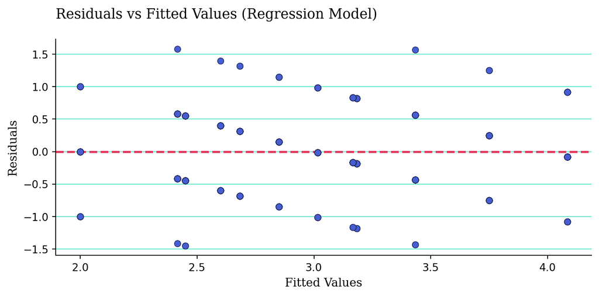

```python
# Extract fitted values and residuals
fitted_values = reg_full.fittedvalues
reg_residuals = reg_full.resid

# Residuals vs fitted values plot
fig, ax = plt.subplots(figsize=(8, 4))

sns.scatterplot(
    x=fitted_values,
    y=reg_residuals,
    ax=ax,
    color='#475ED1',
    edgecolor='#141F52',
    zorder=3
)

ax.axhline(0, color='#E2365B', linestyle='--', linewidth=2)

ax.set_title(
    'Residuals vs Fitted Values (Regression Model)',
    fontsize=13,
    loc='left',
    family='serif',
    pad=20
)
ax.set_xlabel('Fitted Values', fontsize=11, family='serif')
ax.set_ylabel('Residuals', fontsize=11, family='serif')
ax.grid(axis='y', linestyle='-', alpha=0.8, color='#36E2BD', zorder=0)
ax.spines['top'].set_visible(False)
ax.spines['right'].set_visible(False)

plt.tight_layout()
# plt.savefig('../results/plots/regression_residuals_fitted.pdf', bbox_inches='tight')
plt.show()
```

The residuals versus fitted values plot helps assess whether the residual variance is approximately constant. A random scatter of points around zero would support the homoskedasticity assumption, while clear patterns would suggest potential heteroskedasticity or model misspecification.

We can also conduct a Breusch-Pagan test for heteroskedasticity.

```python
# Breusch-Pagan test
bp_test = het_breuschpagan(reg_full.resid, reg_full.model.exog)

bp_results = pd.DataFrame({
    "Statistic": ["Lagrange multiplier statistic", "LM p-value", "F-statistic", "F p-value"],
    "Value": bp_test
})

bp_results
```

|  | Statistic | Value |
| --- | --- | --- |
| 0 | Lagrange multiplier statistic | 4.496668 |
| 1 | LM p-value | 0.953079 |
| 2 | F-statistic | 0.404501 |
| 3 | F p-value | 0.954341 |

If the p-value is below 0.05, this suggests evidence of heteroskedasticity. In that case, the robust standard errors reported above are especially useful.

### Interpretation of Regression Results

The regression results are consistent with the ANOVA framework. Media attention, exposure level, and industry are associated with differences in buying intention.

The main-effects model provides a simpler interpretation of the average effects of each factor. The full interaction model provides a richer specification because it allows the effect of media attention to vary depending on exposure level and industry.

The interaction terms are especially important. Since the model includes interactions between `media_attention`, `exposure_level`, and `industry`, the effect of one variable should not be interpreted completely in isolation. For example, the effect of high exposure may differ depending on whether the stock is presented through Google Search, News, or Social Media. Similarly, the effect of media attention may differ across industries.

Because the dependent variable is ordinal, the OLS results should be interpreted as approximate differences in average buying intention rather than exact changes in a continuous outcome.

## 4.3. Post-Hoc Analysis

To further explore the significant effects found in the ANOVA, we perform post-hoc pairwise comparisons using Tukey’s HSD test. This allows us to identify which specific groups differ from each other in terms of buying intention.

```python
from statsmodels.stats.multicomp import pairwise_tukeyhsd

# Perform Tukey's HSD test for media_attention
tukey_media = pairwise_tukeyhsd(
    endog=data['buying_intention'],
    groups=data['media_attention'],
    alpha=0.05
)

print(tukey_media)

# Perform Tukey's HSD test for exposure_level
tukey_exposure = pairwise_tukeyhsd(
    endog=data['buying_intention'],
    groups=data['exposure_level'],
    alpha=0.05
)

print(tukey_exposure)

# Perform Tukey's HSD test for industry
tukey_industry = pairwise_tukeyhsd(
    endog=data['buying_intention'],
    groups=data['industry'],
    alpha=0.05
)

print(tukey_industry)
```

```
     Multiple Comparison of Means - Tukey HSD, FWER=0.05
==============================================================
    group1       group2    meandiff p-adj lower  upper  reject
--------------------------------------------------------------
Google Search         News   0.3667   0.0 0.2109 0.5224   True
Google Search Social Media   0.8292   0.0 0.6734 0.9849   True
         News Social Media   0.4625   0.0 0.3067 0.6183   True
--------------------------------------------------------------
Multiple Comparison of Means - Tukey HSD, FWER=0.05
===================================================
group1 group2 meandiff p-adj  lower   upper  reject
---------------------------------------------------
  High    Low  -0.7778   0.0 -0.8803 -0.6753   True
---------------------------------------------------
   Multiple Comparison of Means - Tukey HSD, FWER=0.05
=========================================================
  group1     group2   meandiff p-adj lower  upper  reject
---------------------------------------------------------
Industry A Industry B   0.4389   0.0 0.3261 0.5517   True
---------------------------------------------------------
```

The post-hoc tests help determine which specific group differences are statistically significant. For `media_attention`, the pairwise comparisons indicate whether buying intention differs significantly between Google Search, News, and Social Media. For `exposure_level`, the test compares high exposure and low exposure. For `industry`, the test compares Industry A and Industry B.

These tests complement the ANOVA and regression results by identifying the specific category-level differences driving the overall effects.

## 4.4. Visualization of Interaction Effects

To visualize the interaction effects between `media_attention` and `exposure_level`, we create an interaction plot. This helps us understand how the effect of media attention on buying intention changes across different levels of exposure.

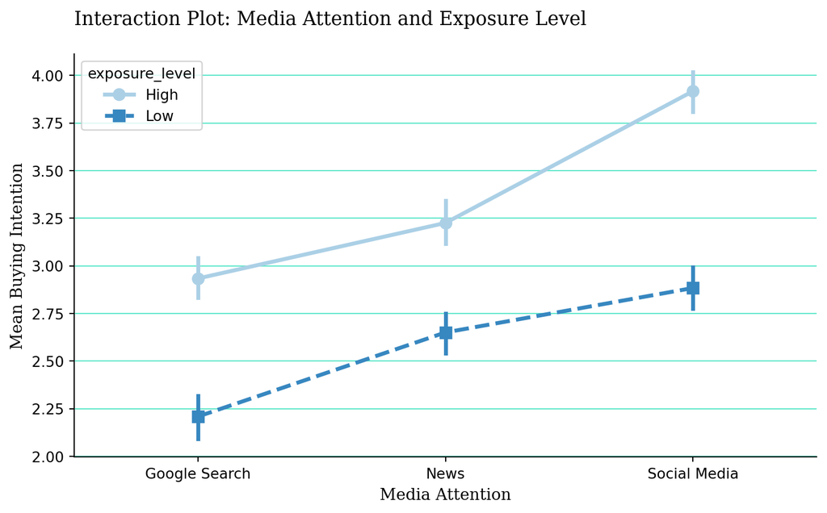

```python
# Create an interaction plot
fig, ax = plt.subplots(figsize=(8, 5))

sns.pointplot(
    x='media_attention',
    y='buying_intention',
    hue='exposure_level',
    data=data,
    ax=ax,
    palette='Blues',
    markers=['o', 's'],
    linestyles=['-', '--']
)

ax.set_title(
    'Interaction Plot: Media Attention and Exposure Level',
    fontsize=13,
    loc='left',
    family='serif',
    pad=20
)
ax.set_xlabel('Media Attention', fontsize=11, family='serif')
ax.set_ylabel('Mean Buying Intention', fontsize=11, family='serif')
ax.grid(axis='y', linestyle='-', alpha=0.8, color='#36E2BD')
ax.spines['top'].set_visible(False)
ax.spines['right'].set_visible(False)

plt.tight_layout()
# plt.savefig('../results/plots/interaction_plot.pdf', bbox_inches='tight')
plt.show()
```

The interaction plot shows whether buying intention differs across media types depending on exposure level. If the lines are not parallel, this suggests an interaction between media attention and exposure level. In particular, if high exposure produces a larger increase in buying intention for one media type than another, this supports the idea that exposure and media type jointly influence investor behavior.

# 5. Discussion of Results

The bivariate analysis and EDA plots served as an exploratory step: they provided a first visual intuition that buying intention differed across media attention, exposure level, and industry. In particular, the boxplots suggested higher buying intention under Social Media, High Exposure, and Industry B, while the distribution plot showed that buying intention was sufficiently spread across the 1–5 scale to allow group comparisons. However, these plots should not be treated as final results because they are descriptive, consider each factor separately, and do not formally test statistical significance. The ANOVA is therefore the central result, because it evaluates all factors simultaneously and tests both main effects and interaction effects.

The three-way ANOVA confirms the main patterns suggested by the exploratory analysis. It shows significant main effects for all three independent variables. Exposure level has the strongest effect, $F(1, 708) = 339.12, p < .001, \eta^2_p = 0.324$, followed by media attention, $F(2, 708) = 129.04, p < .001, \eta^2_p = 0.267$, and industry, $F(1, 708) = 107.98, p < .001, \eta^2_p = 0.132$. This means that buying intention is significantly affected by the level of exposure, the type of media attention, and the industry of the stock

The strongest conclusion concerns exposure level. Its large effect size suggests that high visibility meaningfully increases buying intention. This supports the behavioral finance idea that attention can influence investment decisions: when a stock is more visible, investors may perceive it as more relevant, familiar, or worth considering. Media attention also plays an important role. The regression results clarify the direction of this relationship: compared with the reference media category, News is associated with a higher predicted buying intention, while Social Media has an even larger positive coefficient. This is consistent with the EDA intuition, but the formal tests provide stronger evidence that the media channel itself matters.

The interaction results add an important nuance. The ANOVA finds a significant interaction between media attention and exposure level, $F(2, 708) = 10.20, p < .001, \eta^2_p = 0.028$, meaning the effect of exposure is not identical across media channels. The interaction plot can be mentioned here as a visual illustration: it shows that high exposure raises buying intention across media types, with the strongest pattern appearing for Social Media. However, the other interaction effects are not significant: media attention × industry, $p = 0.875$; exposure level × industry, $p = 0.599$; and the three-way interaction, $p = 0.273$. Therefore, the results support an interaction between media type and exposure, but not the idea that industry substantially changes these interaction patterns.

Overall, the formal statistical results show that attention signals matter for retail investor behavior. The EDA and bivariate analysis helped reveal the initial patterns, but the ANOVA confirms which effects are statistically meaningful. The findings support the hypotheses that exposure level, media attention, and industry influence buying intention, while only partially supporting the hypothesis about interaction effects. The main implication is that buying intention is shaped not only by the stock itself, but also by how visible the stock is and through which media channel that visibility appears.

# Further Steps

The tasks to be finished for the project are the following:

| Task | Description | Status |
| --- | --- | --- |
| Initial EDA and ANOVA | Conduct an exploratory data analysis and perform a three-way ANOVA to test the main effects and interactions of the independent variables on buying intention. | ✅ |
| Further Statistical Analysis | Conduct a linear regression analysis with main effects, interaction effects, model comparison, robust standard errors, and regression diagnostics. | ✅ |
| Discussion of Results | Write a full, detailed, and comprehensive discussion of the results, including interpretation of the ANOVA and regression findings, as well as the implications for behavioral finance. | ❌ |
| Slides | Create LaTeX slides for the final presentation, following the structure and formatting guidelines provided. | ❌ |

**WarningDeadline**

To make sure that the final slides are ready for May 18, we should aim to finish all inputs by May 15. This will give us a few days to build and polish the slides before the final presentation.